# CMPS 242 Homework Assignment 3

## Sanjay Krishna Gouda

#### Results

[output not shown]

[output not shown]

### Implementing Logistic Regression with Batch Gradient Descent.

#### Logistic Regression hypothesis:

$$ y^{'} = sigmoid(X.w) $$

With cost function $$ J(w) = \frac{1}{m}\sum_{i=1}^{m}\big[-y^{(i)}\, log\,( h_w\,(x^{(i)}))-(1-y^{(i)})\,log\,(1-h_w(x^{(i)}))\big]+\frac{\lambda}{2m}\sum_{j=1}^{m}w_j^2$$ or in the vectorized form $$ J(w) = \frac{1}{m}\big((\,log\,(g(Xw))^Ty+(\,log\,(1-g(Xw))^T(1-y)\big)+\frac{\lambda}{m}(\vert\vert w \vert\vert^2_2)$$ where m is the number of examples and g(z) is the sigmoidal activation given by $$ g(z)=\frac{1}{1+e^{−z}} $$

Choosing regularizer (the $\lambda$) value based on 10 fold cross validation scores.

Adding regularizer to the cost function. Initially, just the L2 norm of weights but in later cells, other norms. (for extra credit).

In the cell below:

- import train and test csvs
- map spam/ham to 1/0
- remove stop words from train file
- use tf-idf and vectorize the train file
- use the vocabulary of the above vectorization and vectorize the test file
- print the shapes of train and test matrices with last column being the mapped labels

*the matrix built using tfidfvectorizer normalizes the matrix by default using norm = 'l2'*

```python
import pandas as pd
import numpy as np
import math,os,time,itertools
import matplotlib.pyplot as plt
import pylab as pl
import seaborn as sns
from sklearn import metrics
from sklearn.metrics import confusion_matrix
import matplotlib.pyplot as plt
import pylab as pl
import seaborn as sns
%matplotlib inline

os.chdir("M:\Course stuff\Fall 17\CMPS 242\hw3")
data = pd.read_csv("new_train.csv", encoding = "ISO-8859-1")
#mapping spam/ham to 1/0
data['label']=data['label'].map({'spam':1,'ham':0})
y_train = data.iloc[:,data.columns=='label']
# using nltk to remove stopwords
text = data['sms']
import nltk
from nltk.corpus import stopwords
stop = stopwords.words('english')
for i in range(text.shape[0]):
	text[i] = ' '.join([w for w in data['sms'][i].split() if not w in stopwords.words('english')])

# tf-idf on train data
from sklearn.feature_extraction.text import CountVectorizer,TfidfTransformer,TfidfVectorizer
vectorizer = TfidfVectorizer(stop_words = 'english')

#temp_x = vectorizer.fit_transform(text)
x_train = vectorizer.fit_transform(text).toarray()

#storing the vocabulary
vocab_dict = vectorizer.vocabulary_

temp_x = vectorizer.fit_transform(text)
x_train = temp_x.toarray()

# now we have both x and y matrices which are the
# input text and data and corresponding spam/ham labels
import numpy as np
train = np.concatenate((x_train,y_train), axis = 1)
#print(train.shape)

### test data ###

test_data = pd.read_csv("new_test.csv", encoding = "ISO-8859-1")
test_matrix = test_data
test_matrix['label'],test_matrix['sms']=test_data['label'].map({'spam':1,'ham':0}),test_data['sms']

### VECTORIZING WITH TRAIN VOCABULARY ###
temp_test = TfidfVectorizer(stop_words = 'english',vocabulary = vocab_dict).fit_transform(test_matrix['sms']).toarray()
y_test = test_data.iloc[:,test_data.columns=='label']
test = np.concatenate((temp_test,y_test), axis = 1)
print("shape of train matrix %s\nshape of test matrix %s"%(train.shape,test.shape))

def sigmoid(z):
	return(1/(1+np.exp(-z)))
#sigmoid(train[:,-1])


def predict(yhat):
	for _ in range(yhat.shape[0]):
		if yhat[_,0]>=0.5:
			yhat[_,0] = 1
		else:
			yhat[_,0] = 0
	return yhat
```

```
shape of train matrix (3000, 6023)
shape of test matrix (2572, 6023)
```

**costfn**
Inputs : weights vector, training matrix (including labels) and regularizer that defaults to $\lambda$ = 0.01
Splits the input training matrix into x and y matrices where y is the last column and x is all columns except the last. This matrix *x* is the one I use for training.
Returns the cost based on the equation: $$ J(w) = \frac{1}{m}\big((\,log\,(g(Xw))^Ty+(\,log\,(1-g(Xw))^T(1-y)\big)$$ without regularization and $$ J(w) = \frac{1}{m}\big((\,log\,(g(Xw))^Ty+(\,log\,(1-g(Xw))^T(1-y)\big)+\frac{\lambda}{m}(\vert\vert w \vert\vert^2_2)$$ where m is the number of examples and g(z) is the sigmoidal activation given by $$ g(z)=\frac{1}{1+e^{−z}} $$

**grads**
Inputs: Returns the gradient of cost function taken with respect to w. This is given by $$ \frac{\delta J(w)}{\delta w_{j}} = \frac{1}{m} X^T(g(Xw)-y)$$ without regularization and $$ \frac{\delta J(w)}{\delta w_{j}} = \frac{1}{m} X^T(g(Xw)-y) + \frac{\lambda}{m}w_{j}$$ with L2 regularization

```python
def costfn(w,matrix,reg = 0.01, penalty = 'l1'):
	m = matrix.shape[0]
	x= matrix[:,:-1]
	y= matrix[:,-1]
	h = sigmoid(np.dot(x,w))
	if penalty == 'l1':
		cost = -(1/m)*(np.log(h).T.dot(y)+np.log(1-h).T.dot(1-y))+(reg/(2*m))*np.square(np.linalg.norm(w))
	if penalty == 'l2':
		cost = -(1/m)*(np.log(h).T.dot(y)+np.log(1-h).T.dot(1-y))+(reg/(2*m))*np.square(np.linalg.norm(w,ord =1)) # l1 norm
	return cost[0]

def grads(w,matrix,reg = 0.01, penalty = 'l1'):
	#print(matrix.shape)#calculates the derivative of cost function at the given w
	m = matrix.shape[0]
	x= matrix[:,:-1]
	y= matrix[:,-1]
	w_reg = w
	h = sigmoid(np.dot(x,w)) #yhat
	yhatdiffy = np.subtract(h,y.reshape(y.shape[0],1))
	if penalty == 'l1':
		grad = np.add((1/m)*(x.T.dot(yhatdiffy)),(reg/m)*(w))
	if penalty == 'l2':
		grad = np.add((1/m)*(x.T.dot(yhatdiffy)),(reg/m)*np.sign(w))
	return grad.reshape(grad.shape[0],1)
```

**bgd_optimizer(w,matrix,n_iters = 100,reg = 0.01, penalty = 'l2'):**

##### Batch gradient descent function

```python
def bgd_optimizer(w,matrix,n_iters = 100,reg = 0.01, penalty = 'l2'):

	# updates the weights matrix by computing the delta over entire input matrix #
	# w := w- sum(delta(wx-y))
	for i in range(1,n_iters+1):
		learning_rate = 100*np.power(i,-0.9)  #eta = eta0*(iteration^-0.9)
		delta = grads(w,matrix = matrix,reg = reg, penalty = penalty)
		w = w - learning_rate * (delta) # w:= w - delta*()
		#if i%250==0:
			#print("\t iteration %d of %d. Cost = %r"%(i,n_iters,costfn(w,matrix = matrix ,reg = reg,penalty = penalty)))
	return w
```

**minibatch_optimizer(n_iters,batch_size,w,matrix,reg = 0.01, print_cost = True):**  
Inputs:

**Algorithm:**

- Actual Learning Rate: $$\eta = \eta_0.t^{-\alpha} $$ where $\alpha =0.9$ here I set $\eta_0 = 1$
- Update Rule: $$ w:= w-\eta.grads(weights = w, matrix = current_batch, reg = reg) $$
- Updates are applied iteratively using the batches.
- Batch construction:  
  Used two pointers with fixed distance which equals the batch size and iteratively around the values each time passing these two pointers as indices of the matrix in the grads() function call.

**Note** : Setting batch_size to 1 gives Stochastic Gradient Descent.

```python
def minibatch_optimizer(w,matrix,n_iters = 100,batch_size = 50,reg = 0.01, penalty = 'l2'):
	for i in range(1,n_iters+1):
		np.random.shuffle(matrix) #shuffle data first
		init = 0
		b_s = init+batch_size
		batches = int(matrix.shape[0]/batch_size) #total number of batches
		learning_rate = 1*np.power(i,-0.9)  #eta = eta0*(iteration^-0.9)
		if batches == matrix.shape[0]:
			for j in range(batches-1):
				#print(init,init+1)
				delta = grads(w,matrix = matrix[init:init+1,:],reg = reg, penalty = penalty)
				w = w - learning_rate * (delta)
				init += 1
			last = matrix[-2:-1,:]
			w = w - learning_rate*(grads(w,matrix = last,reg = reg, penalty = penalty))
		#if i%500==0:
			#print("\niteration %d of %d"%(i,n_iters))
			#current_cost = costfn(w,matrix = matrix ,reg = reg,penalty = penalty)
			#print("current cost = ",current_cost)
		# update rule applied to each batch
		if batches != matrix.shape[0]:
			for j in range(1,batches+1):
				if b_s > matrix.shape[0]: #in case batch size is not a multiple of shape
					b_s = b_s - matrix.shape[0]
					delta = grads(w,matrix = matrix[:-b_s,:],reg = reg, penalty = penalty)
					w = w - learning_rate * (delta)

				if b_s < matrix.shape[0]:
					delta = grads(w,matrix = matrix[init:b_s,:],reg = reg, penalty = penalty)
					w = w - learning_rate * (delta) # w:= w - delta*()
					init = b_s+1
					b_s += batch_size
	return w
```

#### Helper function to plot the confusion matrix

```python
def plot_confusion_matrix(cm, classes=['ham','spam'],
                          normalize=False,
                          title='Confusion matrix',
                          cmap=plt.cm.Blues):
    """
    This function prints and plots the confusion matrix.
    Normalization can be applied by setting `normalize=True`.
    """
    if normalize:
        cm = cm.astype('float') / cm.sum(axis=1)[:, np.newaxis]
        print("Normalized confusion matrix")
    else:
        print('Confusion matrix, without normalization')

    print(cm)

    plt.imshow(cm, interpolation='nearest', cmap=cmap)
    plt.title(title)
    plt.colorbar()
    tick_marks = np.arange(len(classes))
    plt.xticks(tick_marks, classes, rotation=45)
    plt.yticks(tick_marks, classes)

    fmt = '.2f' if normalize else 'd'
    thresh = cm.max() / 2.
    for i, j in itertools.product(range(cm.shape[0]), range(cm.shape[1])):
        plt.text(j, i, format(cm[i, j], fmt),
                 horizontalalignment="center",
                 color="white" if cm[i, j] > thresh else "black")

    plt.tight_layout()
    plt.ylabel('True label')
    plt.xlabel('Predicted label')
```

Implementing 10 fold cross validation to selct the $\lambda$ value.

The sklearn package has a function KFold that returns cv indices based on number of splits.

Iteratively called the batch gradient descent optimizer on the CV indices to build corresponding models.

```python
from sklearn.model_selection import KFold
def kfold(matrix,w,n_splits = 10,n_iters = 100,reg = 0.01, penalty = 'l2'):
    #returns training split and test split
    kf = KFold(n_splits = n_splits)
    kf.get_n_splits(matrix)
    #print(kf)
    w_list = []
    yhat_list = []
    train_acc_list = []
    validation_acc_list = []
    w_f = w
    fold = 1
    for train_index,test_index in kf.split(matrix):
        print("\nfold: %d, reg: %.4f"%(fold,reg))
        fold+=1
        #print("Train indices length : %d, \t Test indices length: %d"%(len(train_index),len(test_index)))
        x_train,x_test = matrix[train_index,:],matrix[test_index,:]
        #print(x_train.shape,x_test.shape)
        w_f = bgd_optimizer(w = w,matrix = matrix[train_index,:],n_iters = n_iters,reg = reg, penalty = penalty)
        #w_list.append(w_f)
        yhat = sigmoid(np.dot(matrix[train_index,:-1],w_f))
        yhat = predict(yhat)
        train_acc_list.append(100*metrics.accuracy_score(matrix[train_index,-1],yhat))
        yhat_valid = metrics.accuracy_score(matrix[test_index,-1],predict(sigmoid(np.dot(matrix[test_index,:-1],w_f))))
        validation_acc_list.append(100*yhat_valid)
    return(np.mean(train_acc_list),np.mean(validation_acc_list),w_f)
```

### Model Selection

For spam detection, misclassification of good texts as spam is more punishable.

Hence, along with accuracy, we may consider selecting a model that has the least number of misclassifications of good texts as spam and highest number of correct spam detection.

i.e the model should have better true positive and false negative scores along with accuracy.

Plotting the confusion matrix for the models obtained with different $\lambda$s gives a better visualization of the scenario.

Building the accuracy vs $ log(\lambda) $ plot and the confusion matrix plots for all the 10 fold cv models with different regularizers.

```python
import math
initial_w = np.random.randn(train.shape[1]-1,1)*0.001/np.sqrt(train.shape[1])
reg_list = [pow(10,x) for x in range(-3,2)]
train_acc_list = []
valid_acc_list = []
wts_fold_list = {}
start = time.time()
for reg in reg_list:
    train_acc,valid_acc,w_f = kfold(train,initial_w,n_splits = 10, n_iters = 500, reg = reg,penalty = 'l2')
    train_acc_list.append(train_acc)
    valid_acc_list.append(valid_acc)
    wts_fold_list[reg] = w_f
end = time.time()
ttl = end - start
hrs = int(ttl/3600)
ttl-=3600*hrs
mins = int(ttl/60)
sec = (ttl)%60
print("Time taken for 10fold cv with \'l2\' penalty for 500 iterations:%d hrs %d mins %f sec :"%(hrs,mins,sec))
```

```
fold: 1, reg: 0.0010

fold: 2, reg: 0.0010

fold: 3, reg: 0.0010

fold: 4, reg: 0.0010

fold: 5, reg: 0.0010

fold: 6, reg: 0.0010

fold: 7, reg: 0.0010

fold: 8, reg: 0.0010

fold: 9, reg: 0.0010

fold: 10, reg: 0.0010

fold: 1, reg: 0.0100

fold: 2, reg: 0.0100

fold: 3, reg: 0.0100

fold: 4, reg: 0.0100

fold: 5, reg: 0.0100

fold: 6, reg: 0.0100

fold: 7, reg: 0.0100

fold: 8, reg: 0.0100

fold: 9, reg: 0.0100

fold: 10, reg: 0.0100

```

[output cut: 45 more lines]

```

fold: 4, reg: 10.0000

fold: 5, reg: 10.0000

fold: 6, reg: 10.0000

fold: 7, reg: 10.0000

fold: 8, reg: 10.0000

fold: 9, reg: 10.0000

fold: 10, reg: 10.0000
Time taken for 10fold cv with 'l2' penalty for 500 iterations:3 hrs 47 mins 32.888173 sec :
```

```
Confusion matrix, without normalization
[[2556   27]
 [  51  366]]
accuracy with reg = 0.00100 : 97.4000
Confusion matrix, without normalization
[[2555   28]
 [  52  365]]
accuracy with reg = 0.01000 : 97.3333
Confusion matrix, without normalization
[[2556   27]
 [  60  357]]
accuracy with reg = 0.10000 : 97.1000
Confusion matrix, without normalization
[[2515   68]
 [  84  333]]
accuracy with reg = 1.00000 : 94.9333
Confusion matrix, without normalization
[[2193  390]
 [ 167  250]]
accuracy with reg = 10.00000 : 81.4333
```

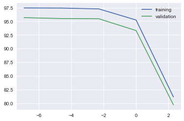

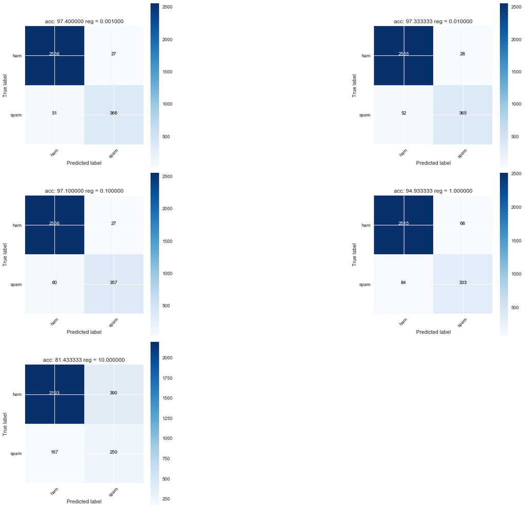

```python
plt.plot(np.log(reg_list),train_acc_list,label = 'training')
plt.plot(np.log(reg_list),valid_acc_list,label = 'validation')
plt.legend()
j=1
plt.figure(figsize=(20,20))
for i in wts_fold_list.keys():
    #plt.subplot(3,3,j)
    j += 1
    ahat = np.dot(train[:,:-1],wts_fold_list[i])
    yhat = sigmoid(ahat)
    plt.subplot(4,4,j)
    j+=1
    yhat = predict(yhat)
    cnf_m = confusion_matrix(train[:,-1],yhat)
    accs = 100*metrics.accuracy_score(train[:,-1],yhat)
    plot_confusion_matrix(cnf_m,title = 'acc: %f reg = %f' %(accs,i))
    print("accuracy with reg = %.5f : %.4f"%(i,accs))
```

```python
train_acc_list_l1 = []
valid_acc_list_l1 = []
wts_fold_list_l1 = {}
start = time.time()
for reg in reg_list:
    train_acc,valid_acc,w_f = kfold(train,initial_w,n_splits = 10, n_iters = 500, reg = reg,penalty = 'l1')
    train_acc_list_l1.append(train_acc)
    valid_acc_list_l1.append(valid_acc)
    wts_fold_list_l1[reg] = w_f
end = time.time()
ttl = end - start
hrs = int(ttl/3600)
ttl-=3600*hrs
mins = int(ttl/60)
sec = (ttl)%60
print("Time taken for 10fold cv with \'l1\' penalty for 500 iterations:%d hrs %d mins %f sec :"%(hrs,mins,sec))
```

```
fold: 1, reg: 0.0010

fold: 2, reg: 0.0010

fold: 3, reg: 0.0010

fold: 4, reg: 0.0010

fold: 5, reg: 0.0010

fold: 6, reg: 0.0010

fold: 7, reg: 0.0010

fold: 8, reg: 0.0010

fold: 9, reg: 0.0010

fold: 10, reg: 0.0010

fold: 1, reg: 0.0100

fold: 2, reg: 0.0100

fold: 3, reg: 0.0100

fold: 4, reg: 0.0100

fold: 5, reg: 0.0100

fold: 6, reg: 0.0100

fold: 7, reg: 0.0100

fold: 8, reg: 0.0100

fold: 9, reg: 0.0100

fold: 10, reg: 0.0100

```

[output cut: 45 more lines]

```

fold: 4, reg: 10.0000

fold: 5, reg: 10.0000

fold: 6, reg: 10.0000

fold: 7, reg: 10.0000

fold: 8, reg: 10.0000

fold: 9, reg: 10.0000

fold: 10, reg: 10.0000
Time taken for 10fold cv with 'l1' penalty for 500 iterations:3 hrs 11 mins 59.009565 sec :
```

```
Confusion matrix, without normalization
[[2556   27]
 [  51  366]]
'l1'.accuracy with reg = 0.00100 : 97.4000
Confusion matrix, without normalization
[[2556   27]
 [  51  366]]
'l1'.accuracy with reg = 0.01000 : 97.4000
Confusion matrix, without normalization
[[2555   28]
 [  51  366]]
'l1'.accuracy with reg = 0.10000 : 97.3667
Confusion matrix, without normalization
[[2555   28]
 [  52  365]]
'l1'.accuracy with reg = 1.00000 : 97.3333
Confusion matrix, without normalization
[[2557   26]
 [  67  350]]
'l1'.accuracy with reg = 10.00000 : 96.9000
```

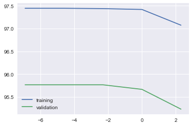

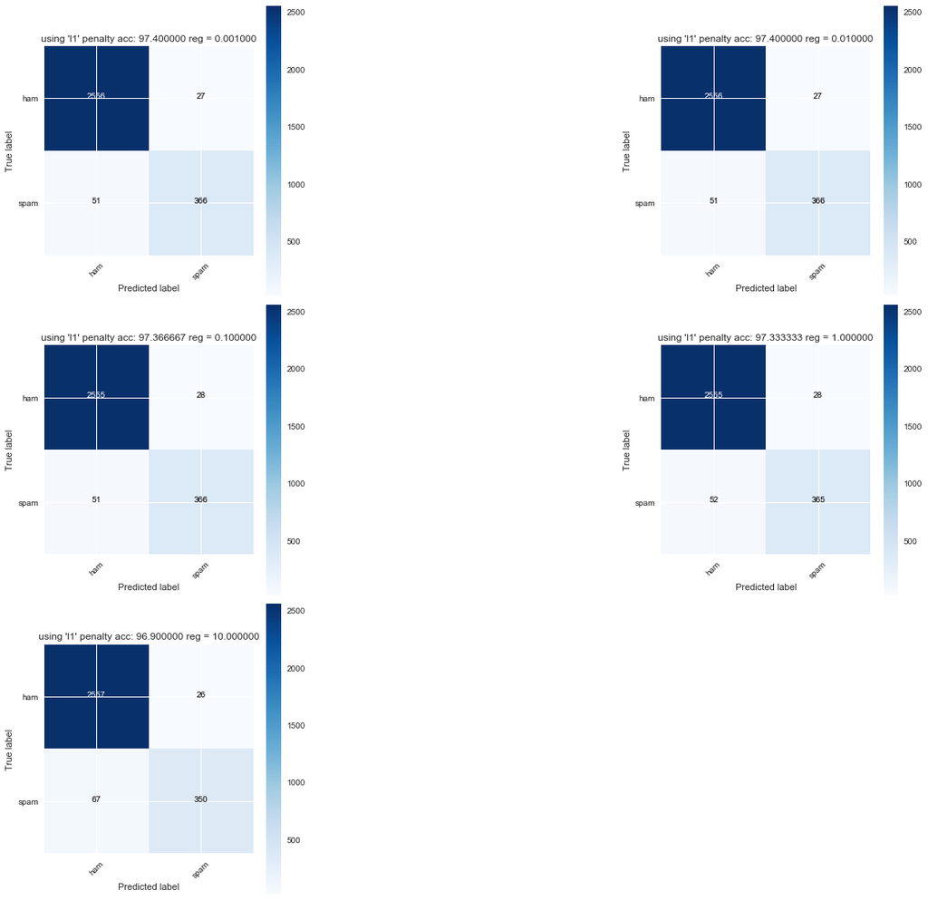

```python
plt.plot(np.log(reg_list),train_acc_list_l1,label = 'training')
plt.plot(np.log(reg_list),valid_acc_list_l1,label = 'validation')
plt.legend()
j=1
plt.figure(figsize=(20,20))
for i in wts_fold_list_l1.keys():
    #plt.subplot(3,3,j)
    j += 1
    ahat = np.dot(train[:,:-1],wts_fold_list_l1[i])
    yhat = sigmoid(ahat)
    plt.subplot(4,4,j)
    j+=1
    yhat = predict(yhat)
    cnf_m = confusion_matrix(train[:,-1],yhat)
    accs = 100*metrics.accuracy_score(train[:,-1],yhat)
    plot_confusion_matrix(cnf_m,title = 'using \'l1\' penalty acc: %f reg = %f' %(accs,i))
    print("\'l1\'.accuracy with reg = %.5f : %.4f"%(i,accs))
```

From the confusion matrix plots we can see that using $\lambda$ = 0.001 gives the optimal result.

In the cell below, let's using the logistic regression hypothesis $$ y^{'} = \big(\,log\,(sigmoid(X.w))\big)$$ on the test data and find the accuracy, confusion matrix. This is the final result.

```
Accuracy on test data with lambda : 0.001000 = 94.129082
Confusion matrix, without normalization
[[2191   51]
 [ 100  230]]
```

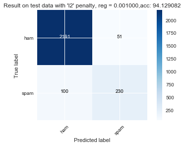

```python
w_final = wts_fold_list[0.001]
yhat = predict(sigmoid(np.dot(test[:,:-1],w_final)))
print("Accuracy on test data with lambda : %f = %f"%(0.001,100*(metrics.accuracy_score(test[:,-1],yhat))))
cnfm_t = confusion_matrix(test[:,-1],yhat)
plot_confusion_matrix(cnfm_t,title = 'Result on test data with \'l2\' penalty, reg = %f,acc: %f' %(0.001,100*(metrics.accuracy_score(test[:,-1],yhat))))
```

## Extra Cedit

```
(3000, 6023)
Time taken for batch gradient descent = 0.537579
Accuracy on test data with lambda : 0.001000 = 94.129082
Confusion matrix, without normalization
[[2193   49]
 [ 102  228]]
```

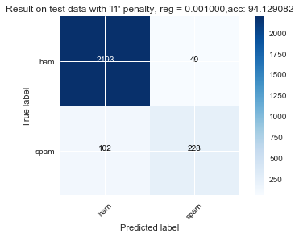

```python
print(train.shape)
start = time.time()
w_withl1 = bgd_optimizer(matrix = train,w = initial_w,n_iters = 500, reg = 0.001,penalty = 'l1')
end = time.time()
print("Time taken for batch gradient descent = %f"%(end-start))
yhat_withl1 = predict(sigmoid(np.dot(test[:,:-1],w_withl1)))
print("Accuracy on test data with lambda : %f = %f"%(0.001,100*(metrics.accuracy_score(test[:,-1],yhat_withl1))))
cnfm_t = confusion_matrix(test[:,-1],yhat_withl1)
plot_confusion_matrix(cnfm_t,title = 'Result on test data with \'l1\' penalty, reg = %f,acc: %f' %(0.001,100*(metrics.accuracy_score(test[:,-1],yhat_withl1))))
```

**Building the model with same hyperparameters but using mini batch gradient descent with batch size = 50**

```
Time taken for mini batch dradient descent with batch size = 50 :15.859135
accuracy:0.7096
Confusion matrix, without normalization
[[2193   49]
 [ 102  228]]
```

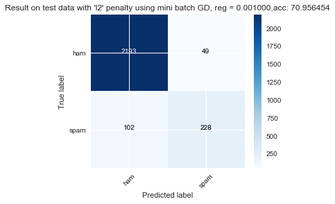

```python
initial_w = np.random.randn(train.shape[1]-1,1)
start = time.time()
w = minibatch_optimizer(w = initial_w, matrix = train,n_iters=500, batch_size = 50, reg = 0.001)
end = time.time()
print("Time taken for mini batch dradient descent with batch size = 50 :%f"%(end-start))
yhat_mb = sigmoid(np.dot(test[:,:-1],w))
yhat_mb = predict(yhat_mb)
print("accuracy:%.4f"%(metrics.accuracy_score(test[:,-1],yhat_mb))) # always ytrue and ypred
plot_confusion_matrix(cnfm_t,title = 'Result on test data with \'l2\' penalty using mini batch GD, reg = %f,acc: %f' %(0.001,100*(metrics.accuracy_score(test[:,-1],yhat_mb))))
```

```
Time taken for stochastic gradient descent:40.631945
accuracy:0.7096
Confusion matrix, without normalization
[[2193   49]
 [ 102  228]]
```

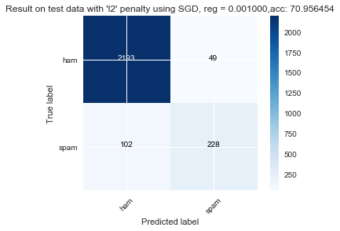

```python
initial_w = np.random.randn(train.shape[1]-1,1)
start = time.time()
w = minibatch_optimizer(w = w, matrix = train,n_iters=500, batch_size = 50, reg = 0.001)
end = time.time()
print("Time taken for stochastic gradient descent:%f"%(end-start))
yhat_sgd = sigmoid(np.dot(test[:,:-1],w))
yhat_sgd = predict(yhat_mb)
print("accuracy:%.4f"%(metrics.accuracy_score(test[:,-1],yhat_sgd))) # always ytrue and ypred
plot_confusion_matrix(cnfm_t,title = 'Result on test data with \'l2\' penalty using SGD, reg = %f,acc: %f' %(0.001,100*(metrics.accuracy_score(test[:,-1],yhat_sgd))))
```

##### Inlcuding bias term and then not regularizing it:

*Concatenating ones vector on the first column*

Note that the last column is still the labels column.

```python
train_bias = np.c_[np.ones((train.shape[0],1)),train]
train_bias.shape
```

```
(3000, 6024)
```

To not regularize the bias term the vectorized equations are as follows: Cost - $$ J(w) = \frac{1}{m}\big((\,log\,(g(Xw))^Ty+(\,log\,(1-g(Xw))^T(1-y)\big)+\frac{\lambda}{m}(\vert\vert w[1:,] \vert\vert^2_2)$$

grads - $w[0,] = 0$ Because the first column is always 1 a constant, it's derivative would be 0. So setting that column values to 0 $$ \frac{\delta J(w)}{\delta w_{j}} = \frac{1}{m} X^T(g(Xw)-y) + \frac{\lambda}{m}w$$ with L2 regularization

```python
train_bias_x = train_bias[:,:-1]
y = train_bias[:,-1]
w_bias = np.random.randn(train_bias_x.shape[1])*0.01/np.sqrt(train_bias_x.shape[0])
def cost_bias(initial_w,x,y,reg):
    m = y.size
    h = sigmoid(np.dot(x,initial_w))
    cost_reg = -1*(1/m)*(np.log(h).T.dot(y)+np.log(1-h).T.dot(1-y)) + (reg/(2*m))*np.sum(np.square(w[1:,:]))
    return cost_reg
#print(cost_bias(w_bias,train_bias_x,y,0.01))

def grads_bias(w,x,y,reg = 0.01, penalty = 'l2'):
	w_reg = w.reshape((w.shape[0],1))#calculates the derivative of cost function at the given w
	m = y.size
	#w_reg = w
	w_reg[:,0]=0 #grad = np.add((1/m)*(x.T.dot(yhatdiffy)),(reg/m)*(w))
	h = sigmoid(np.dot(x,w_reg)) #yhat
	yhatdiffy = np.subtract(h,y.reshape(y.shape[0],1))
	if penalty == 'l2':
		grad = np.add((1/m)*(x.T.dot(yhatdiffy)),(reg/m)*(w_reg))
	return grad.reshape(grad.shape[0],1)
#print(grads_bias(w_bias,train_bias_x,y,0.01).shape)
```

```python
def bgd_optimizer_bias(w,x,y,n_iters = 100,reg = 0.01, penalty = 'l2'):

	# updates the weights matrix by computing the delta over entire input matrix #
	# w := w- sum(delta(wx-y))
	for i in range(1,n_iters+1):
		learning_rate = 5*np.power(i,-0.9)  #eta = eta0*(iteration^-0.9)
		delta = grads_bias(w,x,y,reg = reg, penalty = penalty)
		w = (w.reshape((w.shape[0],1))-learning_rate * (delta)) # w:= w - delta*()
		if i%250==0:
			print("\t iteration %d of %d. Cost = %r"%(i,n_iters,cost_bias(w,x,y,reg = reg)[0]))
	return w
w_opt = bgd_optimizer_bias(w_bias,train_bias_x,y,reg = 0.001,n_iters = 1)
yhat_bias = predict(sigmoid(np.dot(train_bias_x,w_opt).reshape((train_bias_x.shape[0],1))))
print("Accuracy with bias and same model %f"%(100*metrics.accuracy_score(y,yhat_bias)))
```

```
Accuracy with bias and same model 86.100000
```

```python
print("Train accuracy with l2",train_acc_list,"\nValidation accuracy with l2",valid_acc_list,"\nTrain accuracy with l1",train_acc_list_l1,"\nValidation accuracy with l1",valid_acc_list_l1)
```

```
Train accuracy with l2 [97.44074074074075, 97.418518518518525, 97.270370370370372, 95.23333333333332, 81.137037037037047]
Validation accuracy with l2 [95.666666666666657, 95.5, 95.466666666666669, 93.300000000000011, 79.699999999999989]
Train accuracy with l1 [97.444444444444443, 97.444444444444443, 97.437037037037044, 97.418518518518525, 97.074074074074062]
Validation accuracy with l1 [95.76666666666668, 95.76666666666668, 95.76666666666668, 95.666666666666671, 95.233333333333334]
```

```python
start = time.time()
w = minibatch_optimizer(w = w, matrix = train,n_iters=500, batch_size = 3000, reg = 0.001)
end = time.time()
print(end-start)
```

```
24.58913540840149
```